# Simulation Analysis

Author

Tzu-Yao Lin

Published

April 25, 2024

# 1 Simulated data

## 1.1 Multilevel Measurement Error Vector Autoregressive (1) Model

According to Schuurman & Hamaker (2019), the **multilevel MEVAR(1) model** can be written as follows.

- Level 1 model (within subject)
  - Observation equation

$$\begin{pmatrix}y_{1it} \\ y_{2it}\end{pmatrix} = \begin{pmatrix}\mu_{1i} \\ \mu_{2i}\end{pmatrix} + \begin{pmatrix}\theta_{1it} \\ \theta_{2it}\end{pmatrix} + \begin{pmatrix}\epsilon_{1it} \\ \epsilon_{2it}\end{pmatrix}$$

$$\begin{pmatrix}\epsilon_{1it} \\ \epsilon_{2it}\end{pmatrix} \sim \mathcal{N} \left(\begin{pmatrix}0 \\ 0\end{pmatrix}, \mathbf{\Sigma}_{\epsilon i} = \begin{pmatrix} \sigma^2_{\epsilon 11i} & \sigma_{\epsilon 12i} \\ \sigma_{\epsilon 12i} & \sigma^2_{\epsilon 22i}\end{pmatrix}\right)$$

- State equation (state space model representation)

$$\begin{pmatrix}\theta_{1it} \\ \theta_{2it}\end{pmatrix} = \begin{pmatrix} \phi_{11i} & \phi_{12i} \\ \phi_{12i} & \phi_{22i} \end{pmatrix} \begin{pmatrix}\theta_{1it-1} \\ \theta_{2it-1}\end{pmatrix} + \begin{pmatrix}\omega_{1it} \\ \omega_{2it}\end{pmatrix}$$

$$\begin{pmatrix}\omega_{1it} \\ \omega_{2it}\end{pmatrix} \sim \mathcal{N} \left(\begin{pmatrix}0 \\ 0\end{pmatrix}, \mathbf{\Sigma}_{\omega i} = \begin{pmatrix} \sigma^2_{\omega 11i} & \sigma_{\omega 12i} \\ \sigma_{\omega 12i} & \sigma^2_{\omega 22i}\end{pmatrix}\right)$$

- Level 2 model (between subject)

$$\boldsymbol{\mu}_i = \begin{pmatrix}\mu_{1 i} \\\mu_{2 i} \end{pmatrix} \sim \mathcal{N} \left(\boldsymbol{\gamma}_\mu = \begin{pmatrix} \gamma_{\mu 1} \\\gamma_{\mu 2} \end{pmatrix}, \boldsymbol{\Psi}_\mu =\begin{pmatrix} \psi_{\mu1}^2 & \psi_{\mu12} \\ \psi_{\mu12} & \psi_{\mu2}^2\end{pmatrix}\right)$$

$$vec(\boldsymbol{\Phi}_i) = \begin{pmatrix} \phi_{11i} \\ \phi_{12i} \\ \phi_{21i} \\ \phi_{22i} \end{pmatrix} \sim \mathcal{N} \left(\boldsymbol{\gamma}_{\Phi} = \begin{pmatrix}\gamma_{\phi 11} \\ \gamma_{\phi 12} \\ \gamma_{\phi 21} \\ \gamma_{\phi 22} \end{pmatrix}, \boldsymbol{\boldsymbol{\Psi}}_{\phi} = \begin{pmatrix} \psi_{\phi11}^2 & \psi_{\phi11\phi12} & \psi_{\phi11\phi21} & \psi_{\phi11\phi22} \\ \psi_{\phi11\phi12} & \psi_{\phi12}^2 & \psi_{\phi12\phi21} & \psi_{\phi12\phi22} \\ \psi_{\phi21\phi11} & \psi_{\phi21\phi12} & \psi_{\phi21}^2 & \psi_{\phi21\phi22} \\ \psi_{\phi11\phi22} & \psi_{\phi22\phi12} & \psi_{\phi22\phi21} & \psi_{\phi22}^2 \end{pmatrix} \right)$$

$$\begin{align*}
\mathbf{\Sigma}_{\epsilon i} &= \begin{pmatrix} \sigma^2_{\epsilon 11i} & \sigma_{\epsilon 12i} \\ \sigma_{\epsilon 12i} & \sigma^2_{\epsilon 22i}\end{pmatrix} = \begin{pmatrix}\tau_{\epsilon 1i} \\ \tau_{\epsilon 2i} \end{pmatrix} \begin{pmatrix} 1 & \psi_{\sigma_{\epsilon 12i}} \\ \psi_{\sigma_{\epsilon 12i}} & 1\end{pmatrix} \begin{pmatrix}\tau_{\epsilon 1i} \\ \tau_{\epsilon 2i} \end{pmatrix}^\top = \boldsymbol{\tau}_{\epsilon i} \mathbf{C}_{\epsilon i} \boldsymbol{\tau}_{\epsilon i}^\top \\
\boldsymbol{\tau}_{\epsilon i} &\sim logNormal\left(\boldsymbol{\gamma_{\epsilon}} = \begin{pmatrix}\gamma_{\epsilon 1} \\ \gamma_{\epsilon 2}\end{pmatrix}, \boldsymbol{\Phi_\epsilon} = \begin{pmatrix} \psi_{\epsilon 1}^2 & 0 \\ 0 & \psi_{\epsilon 2}^2\end{pmatrix}\right) \\
\mathbf{C}_{\epsilon i} &\sim LKJ(\eta_\epsilon)
\end{align*}$$

$$\begin{align*}
\mathbf{\Sigma}_{\omega i} &= \begin{pmatrix} \sigma^2_{\omega 11i} & \sigma_{\omega 12i} \\ \sigma_{\omega 12i} & \sigma^2_{\omega 22i}\end{pmatrix} = \begin{pmatrix}\tau_{\omega 1i} \\ \tau_{\omega 2i} \end{pmatrix} \begin{pmatrix} 1 & \psi_{\sigma_{\epsilon 12i}} \\ \psi_{\sigma_{\epsilon 12i}} & 1\end{pmatrix} \begin{pmatrix}\tau_{\omega 1i} \\ \tau_{\omega 2i} \end{pmatrix}^\top = \boldsymbol{\tau}_{\omega i} \mathbf{C}_{\omega i} \boldsymbol{\tau}_{\omega i}^\top \\
\boldsymbol{\tau}_{\omega i} &\sim logNormal\left(\boldsymbol{\gamma_{\omega}} = \begin{pmatrix}\gamma_{\omega 1} \\ \gamma_{\omega 2}\end{pmatrix}, \boldsymbol{\Phi_\omega} = \begin{pmatrix} \psi_{\omega 1}^2 & 0 \\ 0 & \psi_{\omega 2}^2\end{pmatrix}\right) \\
\mathbf{C}_{\omega i} &\sim LKJ(\eta_\omega)
\end{align*}$$

## 1.2 Reliability

- **Reliability for systematic between-subject difference**

$$R^B_p = \frac{\psi^2_{\mu p}}{Var(y_p)} = \frac{\psi^2_{\mu p}}{\psi^2_{\mu p} + E_{i}[\tau_{p i}]+ E[\sigma_{\epsilon pp i}^2]}$$

where $p = 1, 2$. Since $\tau_{\epsilon pi} \sim logNotmal(\tau_{\epsilon p}, \psi_{\epsilon p}^2)$, $\sigma_{\epsilon ppi}^2 = \tau_{\epsilon pi}^2 \sim \sim logNotmal(2\tau_{\epsilon p}, 4\psi_{\epsilon p}^2)$. Therefore, $E[\sigma_{\epsilon pp i}^2] = e^{2\tau_{\epsilon p} + 4\psi_{\epsilon p}^2 / 2}$

- **Reliability for within-subject fluctuations**

$$R_{pi}^W = \frac{\tau_{pi}}{Var(y_{i})} = \frac{\tau_{pi}}{\tau_{pi} + \sigma_{\epsilon ppi}^2}$$

where $\tau_i = \frac{\sigma_{\omega i}^2}{1 - \phi_i^2}$.

## 1.3 Data generating function and (hyper-)parameter settings

```r
#| filename: "data_generation.R"


generate_ssm_data <- function(N, nT, seed = NULL, init = NULL) {
  if (!is.null(seed))  set.seed(seed)

  # data saving structure
  y <- rep(list(matrix(0, nrow = 2, ncol = nT)), N)
  mu <- vector("list", N)
  theta <- rep(list(matrix(0, nrow = 2, ncol = nT)), N)
  theta0 <- vector("list", N)
  Phi <- vector("list", N)
  epsilon <- vector("list", N)
  omega <- vector("list", N)
  tau_epsilon <- vector("list", N)
  Cor_epsilon <- vector("list", N)
  Sigma_epsilon <- vector("list", N)
  tau_omega <- vector("list", N)
  Cor_omega <- vector("list", N)
  Sigma_omega <- vector("list", N)
  Tau <- vector("list", N)
  rel_B <- NA_real_
  rel_W <- vector("list", N)

  # hyper-parameter settings
  m0 <- c(0, 0)
  C0 <- diag(c(10, 10))

  gamma_mu <- c(50, 20)
  Psi_mu <- diag(c(500, 500))

  gamma_Phi <- c(0.5, 0.2, -0.3, -0.3)
  Psi_Phi <- diag(c(0.1, 0.05, 0.05, 0.1))

  gamma_tau_epsilon <- c(1.2, 1.1)
  diag_Psi_tau_epsilon <- c(1, 0.8)
  eta_Cor_epsilon <- 3

  gamma_tau_omega <- c(-0.8, 1)
  diag_Psi_tau_omega <- c(0.5, 0.8)
  eta_Cor_omega <- 5

  # generate parameters
  for (n in 1:N) {
    mu[[n]] <- MASS::mvrnorm(1, gamma_mu, Psi_mu)

    Phi[[n]] <- MASS::mvrnorm(1, gamma_Phi, Psi_Phi) |> matrix(2, 2)

    tau_epsilon[[n]] <- rlnorm(2, gamma_tau_epsilon, sqrt(diag_Psi_tau_epsilon))
    Cor_epsilon[[n]] <- rethinking::rlkjcorr(1, 2, eta_Cor_epsilon)
    Sigma_epsilon[[n]] <- diag(tau_epsilon[[n]]) %*% Cor_epsilon[[n]] %*% diag(tau_epsilon[[n]])

    tau_omega[[n]] <- rlnorm(2, gamma_tau_omega, sqrt(diag_Psi_tau_omega))
    Cor_omega[[n]] <- rethinking::rlkjcorr(1, 2, eta_Cor_omega)
    Sigma_omega[[n]] <- diag(tau_omega[[n]]) %*% Cor_omega[[n]] %*% diag(tau_omega[[n]])
  }

  # generate data
  for (n in 1:N) {
    theta0[[n]] <- MASS::mvrnorm(1, m0, C0)

    omega[[n]] <- MASS::mvrnorm(nT, c(0, 0), Sigma_omega[[n]]) |> t()
    theta[[n]][, 1] <- Phi[[n]] %*% theta0[[n]] + omega[[n]][, 1]
    for (t in 2:nT) {
      theta[[n]][, t] <- Phi[[n]] %*% theta[[n]][, t-1] + omega[[n]][, t]
    }

    epsilon[[n]] <- MASS::mvrnorm(nT, c(0, 0), Sigma_epsilon[[n]]) |> t()
    y[[n]] <- mu[[n]] + theta[[n]] + epsilon[[n]]

  }

  # reliability
  for (n in 1:N) {
    Tau[[n]] <- solve((diag(c(1, 1, 1, 1)) - Phi[[n]] %x% Phi[[n]]),
                 c(Sigma_omega[[n]])) |>
      matrix(nrow = 2)

    rel_W[[n]] <- diag(Tau[[n]]) / diag(Tau[[n]] + Sigma_epsilon[[n]])
  }
  mean_Tau <- Reduce("+", Tau) / length(Tau)
  mean_Sigma2_epsilon <- exp(gamma_tau_epsilon * 2 + diag_Psi_tau_epsilon[1] * 4 / 2)

  rel_B <- diag(Psi_mu) / (diag(Psi_mu) + diag(mean_Tau) + mean_Sigma2_epsilon)

  # return
  return(list(
    N = N,
    nT = nT,
    y = y,
    theta = theta,
    theta0 = theta0,
    mu = mu,
    Phi = Phi,
    tau_epsilon = tau_epsilon,
    Cor_epsilon = Cor_epsilon,
    Sigma_epsilon = Sigma_epsilon,
    tau_omega = tau_omega,
    Cor_omega = Cor_omega,
    Sigma_omega = Sigma_omega,
    m0 = m0,
    C0 = C0,
    gamma_mu = gamma_mu,
    Psi_mu = Psi_mu,
    gamma_Phi = gamma_Phi,
    Psi_Phi = Psi_Phi,
    gamma_tau_epsilon = gamma_tau_epsilon,
    diag_Psi_tau_epsilon = diag_Psi_tau_epsilon,
    eta_Cor_epsilon = eta_Cor_epsilon,
    gamma_tau_omega = gamma_tau_omega,
    diag_Psi_tau_omega = diag_Psi_tau_omega,
    eta_Cor_omega = eta_Cor_omega,
    rel_W = rel_W,
    rel_B = rel_B
  ))
}
```

## 1.4 Snoop the generated data

```r
library(tidyverse)
theme_set(theme_bw())

# source("data_generation.R")
# gen_data <- generate_ssm_data(N = 25, nT = 50, seed = 1294)
# saveRDS(gen_data, "sim_data/data_N25T50S1294.rds")
gen_data <- readRDS("sim_data/data_N25T50S1294.rds")
```

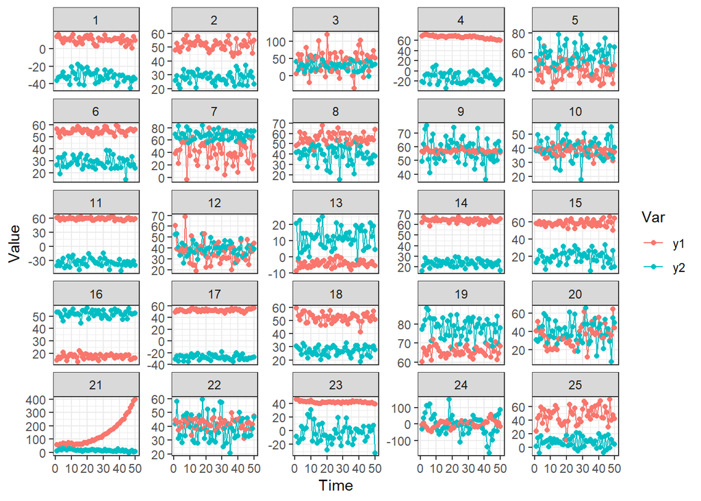

Figure 1: The time plot of observed scores for each subject

```r
plot_data <- tibble(y = gen_data$y) |>
  mutate(Sub = factor(1:n()),
         y1 = map(y, ~ .x[1, ]),
         y2 = map(y, ~ .x[2, ])) |>
  unnest_longer(y1:y2) |>
  pivot_longer(y1:y2, names_to = "Var", values_to = "Value") |>
  mutate(Time = 1:n(), .by = c(Sub, Var))

plot_data |>
  # filter(Sub %in% 1:12) |>
  ggplot(aes(x = Time, y = Value, color = Var)) +
  geom_line() + geom_point() +
  facet_wrap(Sub ~ ., scales = "free_y", nrow = 5)
```

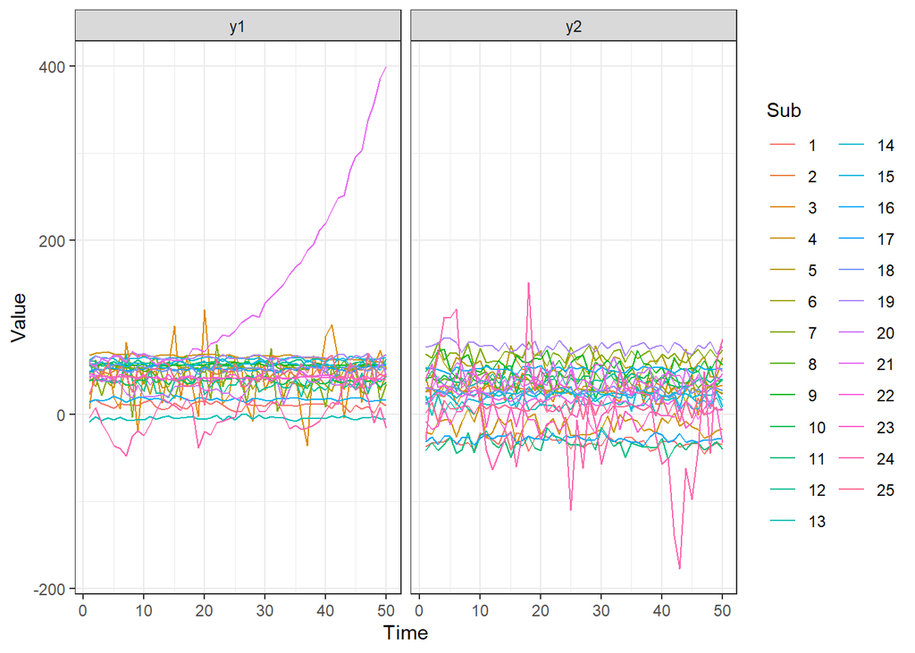

Figure 2: The time plot of observed scores for all subjects together

```r
plot_data |>
  ggplot(aes(x = Time, y = Value, group = Sub, color = Sub)) +
  geom_line() + #geom_point() +
  facet_grid(. ~ Var)
```

## 1.5 Reliability

- Between-level reliability

```r
gen_data$rel_B
```

```
[1] 0.8359755 0.6856167
```

- Within -level reliability

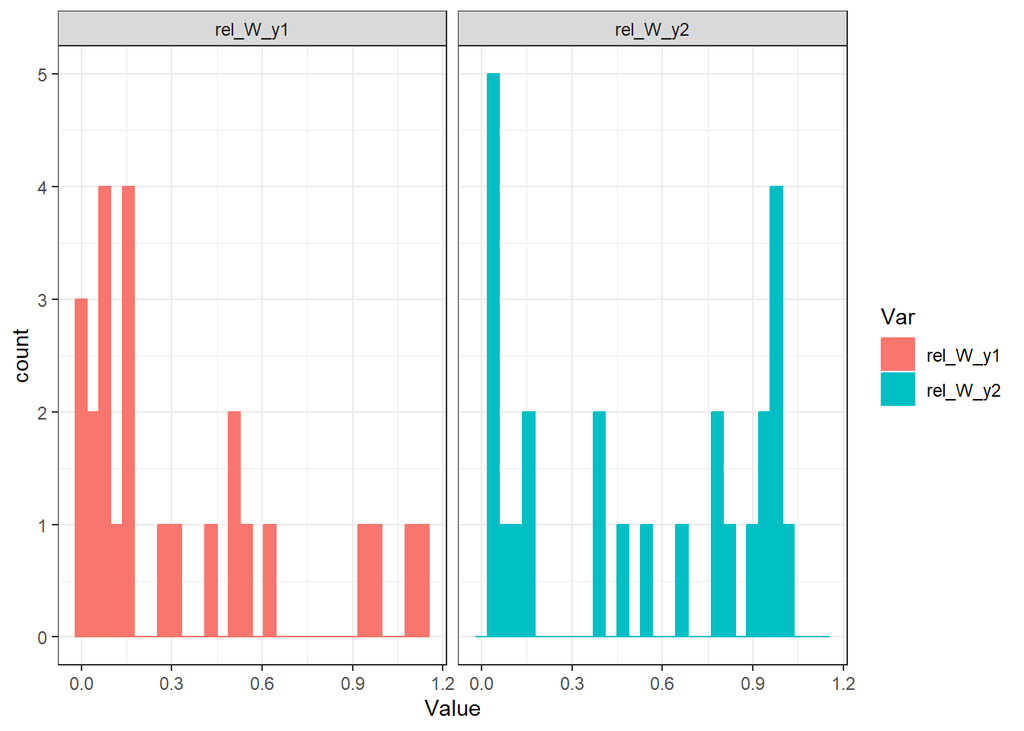

Figure 3: The distribution of within-subject reliability

```r
plot_rel_W <- tibble(rel_W = gen_data$rel_W) |>
  mutate(Sub = factor(1:n()),
         rel_W_y1 = map_dbl(rel_W, ~ .x[1]),
         rel_W_y2 = map_dbl(rel_W, ~ .x[2]), .keep = "none") |>
  pivot_longer(rel_W_y1:rel_W_y2, names_to = "Var", values_to = "Value")

plot_rel_W |>
  ggplot(aes(x = Value, color = Var, fill = Var)) +
  geom_histogram() +
  facet_grid(. ~ Var)
```

# 2 Model fitting by Stan

## 2.1 Stan codes

[output not shown]

### 2.1.1 Fit the model

```r
library(cmdstanr)
register_knitr_engine(override = FALSE)
library(posterior)
library(bayesplot)
color_scheme_set("brewer-Spectral")

source("custom_functions.R")
pos_neg_color <- scales::hue_pal()(2)
```

```r
lkj <- cmdstan_model("stan/multilevel_multivariate_ssm_lkj.stan")

mssm_data <- lst(N = gen_data$N,
                 `T` = gen_data$nT,
                 y = gen_data$y)

output_dir <- "stan/results/ssm_lkj_N25T50_W4000S4000_S1294"
dir.create(output_dir)

lkj_fit <- lkj$sample(data = mssm_data,
                        chains = 6,
                        parallel_chains = 6,
                        iter_warmup = 4000,
                        iter_sampling = 4000,
                        seed = 1294,
                        refresh = 2000,
                        show_messages = TRUE,
                        output_dir = output_dir)
lkj_fit <- as_cmdstan_fit(list.files(output_dir, full.names = TRUE))
lkj_sum <- lkj_fit$summary()
saveRDS(lkj_sum, str_c(output_dir,"/summary.RDS"))
```

### 2.1.2 Check the convergence

```r
lkj_sum <- readRDS("stan/results/ssm_lkj_N25T50_W4000S4000_S1294/summary.RDS")
skimr::skim(lkj_sum |> select(rhat:ess_tail))
```

Data summary

| Name | select(lkj_sum, rhat:ess_… |
| --- | --- |
| Number of rows | 6091 |
| Number of columns | 3 |
| _______________________ |  |
| Column type frequency: |  |
| numeric | 3 |
| ________________________ |  |
| Group variables | None |

**Variable type: numeric**

| skim_variable | n_missing | complete_rate | mean | sd | p0 | p25 | p50 | p75 | p100 | hist |
| --- | --- | --- | --- | --- | --- | --- | --- | --- | --- | --- |
| rhat | 175 | 0.97 | 7.31 | 5.52 | 1.86 | 3.75 | 5.42 | 8.15 | 36.89 | ▇▁▁▁▁ |
| ess_bulk | 175 | 0.97 | 6.60 | 0.79 | 6.02 | 6.15 | 6.35 | 6.74 | 15.93 | ▇▁▁▁▁ |
| ess_tail | 3663 | 0.40 | 7.82 | 5.52 | 6.01 | 6.01 | 6.01 | 6.32 | 53.08 | ▇▁▁▁▁ |

```r
# View(lkj_sum)
```

## 2.2 Change to another model

The following, I used the model used by Schuurman & Hamaker (2019) to fit the data.

```
multilevel_multivariate_ssm_s2019.stan
```

```
#include ssm_function.stan

data {
  int<lower=1> N; // number of subjects
  int<lower=1> T; // number of observation for each subject
  array[N] matrix[2, T] y; // observations
}

transformed data {
  vector[2] m_0; // prior mean of the intial state
  vector[2] diag_C_0; // diagonal of the prior covariance of the intial state

  m_0 = rep_vector(50.0, 2);
  diag_C_0 = rep_vector(sqrt(1000), 2);
}

parameters {
  array[N] vector[2] mu; // ground mean/trane
  array[N] vector[2] theta_0; // initial latent state
  array[N] matrix[2, T] theta; // latent states
  array[N] matrix[2, 2] Phi; // autoregressive parameters

  vector<lower=0>[N] sigma2_epsilon;
  vector<lower=0>[N] sigma2_omega;
  array[N] vector<lower=0>[4] ervar;

  vector[2] gamma_mu; // prior mean of the ground mean
  cov_matrix[2] Psi_mu; // prior covariance of the ground mean
  vector[4] gamma_Phi; // prior mean of the autoregressive parameters
  cov_matrix[4] Psi_Phi; // prior covariance of the autoregressive parameters

  real gamma_log_sigma2_epsilon;
  real<lower=0> psi_log_sigma2_epsilon;
  real gamama_log_sigma2_omega;
  real<lower=0> psi_log_sigma2_omega;
  vector[4] gamma_log_ervar;
  vector<lower=0>[4] psi_log_ervar;
}

transformed parameters {
```

[output cut: 62 more lines]

```
                       2, 2);

    for (p in 1:2) {
      rel_W[n, p] = Tau[n, p, p] / (Tau[n, p, p] + R[n, p, p]);
    }
  }

  // between-subject reliability
  for (p in 1:2) {
    mu_R[p] = exp(gamma_log_sigma2_epsilon + 0.5 * psi_log_sigma2_epsilon^2) +
      exp(gamma_log_ervar[p] + 0.5 * psi_log_ervar[p]^2);

    rel_B[p] = Psi_mu[p, p] / (Psi_mu[p, p] + mean(Tau[, p, p]) + mu_R[p]);
  }
}
```

As for the setting of the covariance matrix of the measurement errors/innovations:

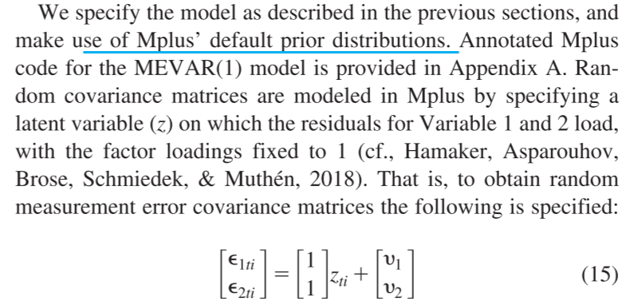

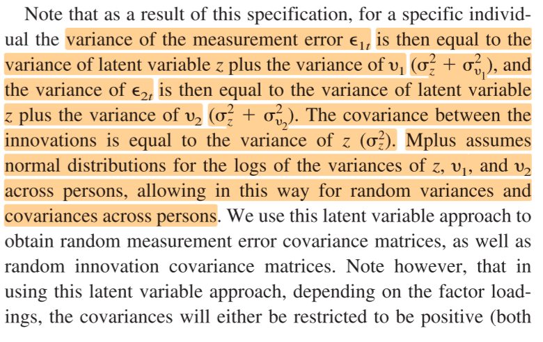

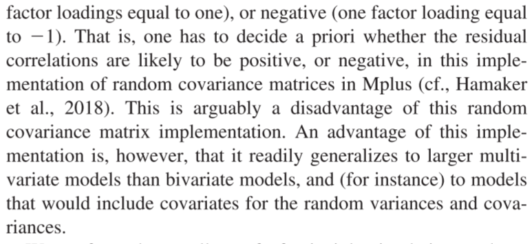

Figure 4: Mplus setting for the covariance matrix of the measurement errors/innovations in Schuurman & Hamaker (2019)

### 2.2.1 Fit the model

```r
mssm <- cmdstan_model("stan/multilevel_multivariate_ssm_s2019.stan")

mssm_data <- lst(N = gen_data$N,
                 `T` = gen_data$nT,
                 y = gen_data$y)

output_dir <- "stan/results/ssm_s2019_N25T50_W4000S4000_S1295"
dir.create(output_dir)

mssm_fit <- mssm$sample(data = mssm_data,
                        chains = 6,
                        parallel_chains = 6,
                        iter_warmup = 4000,
                        iter_sampling = 4000,
                        seed = 1295,
                        refresh = 2000,
                        show_messages = TRUE,
                        output_dir = output_dir)

saveRDS(mssm_fit$summary(), str_c(output_dir,"/summary.RDS"))
```

### 2.2.2 Check the convergence

```r
output_dir <- "stan/results/ssm_s2019_N25T50_W4000S4000_S1295"
mssm_fit <- as_cmdstan_fit(list.files(output_dir, "*.csv", full.names = TRUE))
mssm_sum <- readRDS(str_c(output_dir,"/summary.RDS"))
skimr::skim(mssm_sum |> select(rhat:ess_tail))
```

Data summary

| Name | select(mssm_sum, rhat:ess… |
| --- | --- |
| Number of rows | 5789 |
| Number of columns | 3 |
| _______________________ |  |
| Column type frequency: |  |
| numeric | 3 |
| ________________________ |  |
| Group variables | None |

**Variable type: numeric**

| skim_variable | n_missing | complete_rate | mean | sd | p0 | p25 | p50 | p75 | p100 | hist |
| --- | --- | --- | --- | --- | --- | --- | --- | --- | --- | --- |
| rhat | 0 | 1 | 1.07 | 0.05 | 1.00 | 1.04 | 1.06 | 1.10 | 1.26 | ▇▇▃▁▁ |
| ess_bulk | 0 | 1 | 1114.10 | 1960.38 | 16.59 | 53.80 | 177.97 | 1283.52 | 16051.75 | ▇▁▁▁▁ |
| ess_tail | 0 | 1 | 4536.65 | 3913.97 | 11.18 | 1289.40 | 3251.07 | 7689.10 | 15159.25 | ▇▃▂▂▁ |

```r
# View(mssm_sum)
```

```r
mssm_fit$diagnostic_summary()
```

```
$num_divergent
[1]  973 2098  774  807 1780 2318

$num_max_treedepth
[1] 3027 1902 3226 3193 2218 1416

$ebfmi
[1] 0.02816876 0.02370331 0.02301835 0.02415467 0.01391336 0.02656824
```

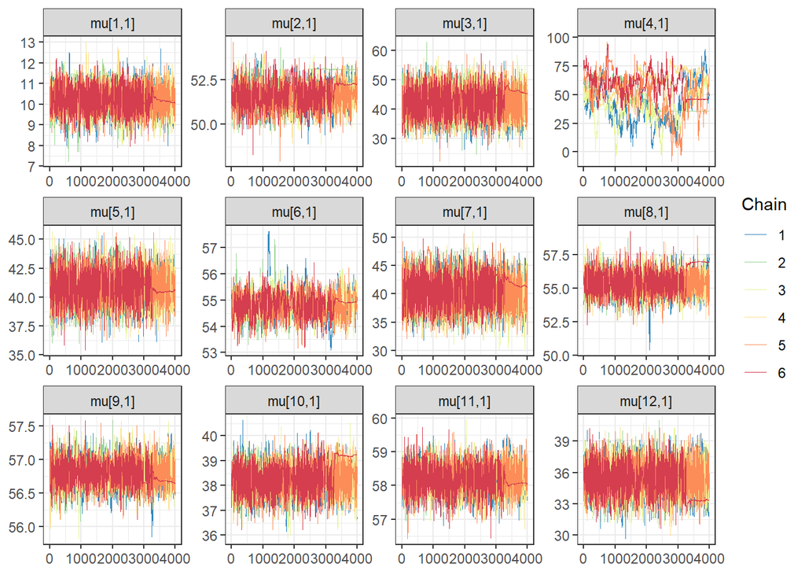

```r
mssm_fit$draws(variables = "mu", format = "df") %>%
  select(1:12, .chain, .iteration, .draw) %>%
  mcmc_trace()
```

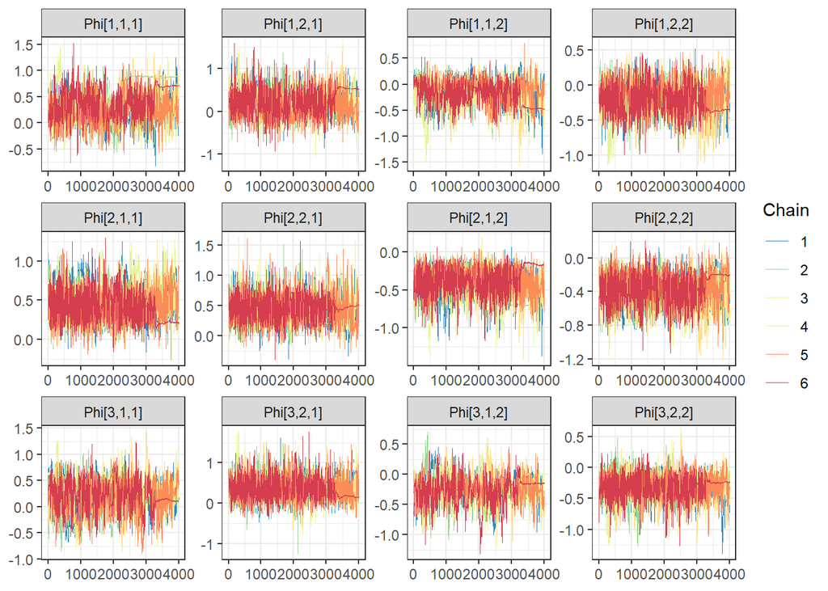

```r
mssm_fit$draws(variables = "Phi", format = "df") %>%
  select(kronecker(1:3, c(0, 25, 50, 75), "+"),
         .chain, .iteration, .draw) %>%
  mcmc_trace()
```

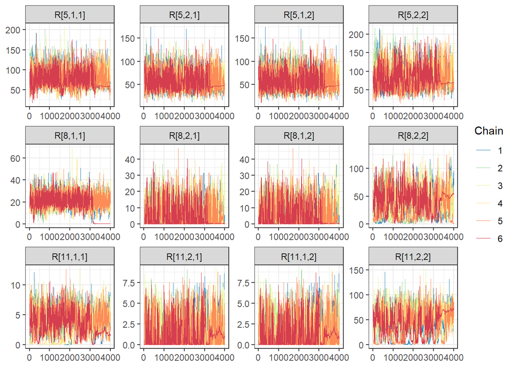

```r
mssm_fit$draws(variables = c("R"), format = "df") %>%
  select(kronecker(c(5, 8, 11), c(0, 25, 50, 75), "+"),
         .chain, .iteration, .draw) %>%
  mcmc_trace()
```

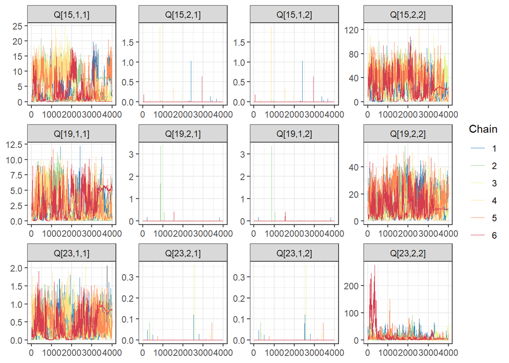

```r
mssm_fit$draws(variables = c("Q"), format = "df") %>%
  select(kronecker(c(15, 19, 23), c(0, 25, 50, 75), "+"),
         .chain, .iteration, .draw) %>%
  mcmc_trace()
```

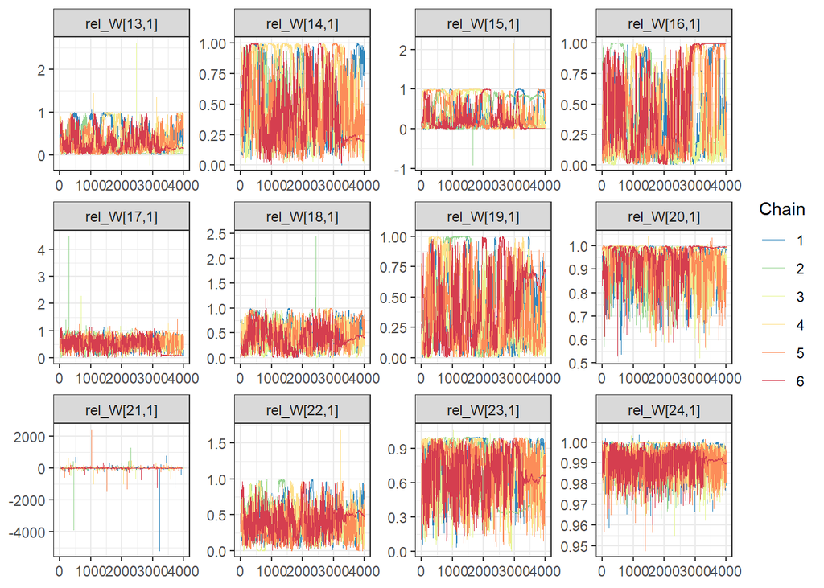

```r
mssm_fit$draws(variables = "rel_W", format = "df") %>%
  select(13:24, .chain, .iteration, .draw) %>%
  mcmc_trace()
```

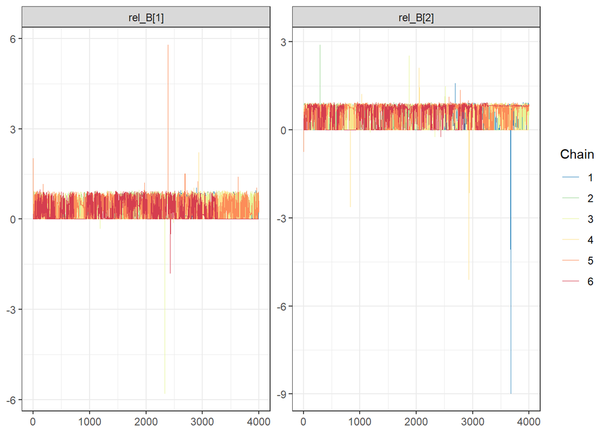

```r
mssm_fit$draws(variables = "rel_B", format = "df") %>%
  mcmc_trace()
```

### 2.2.3 Results

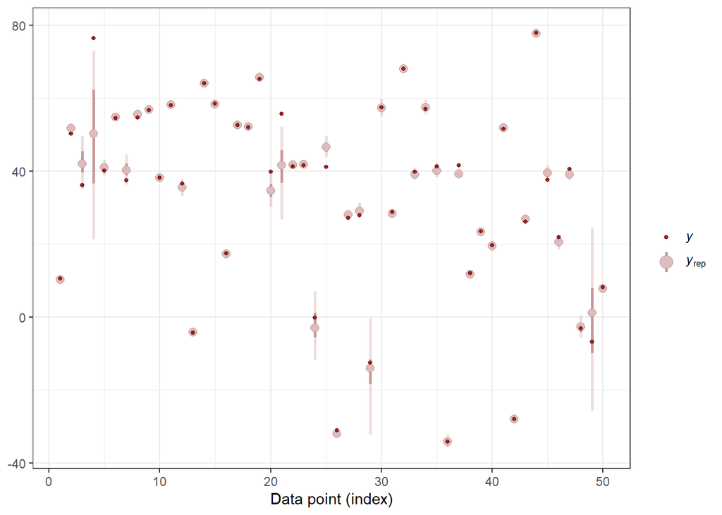

```r
color_scheme_set("red")

ppc_intervals(y = gen_data$mu |> list_transpose() |> list_c(),
              yrep = mssm_fit$draws(variables = "mu", format = "draws_matrix"))
```

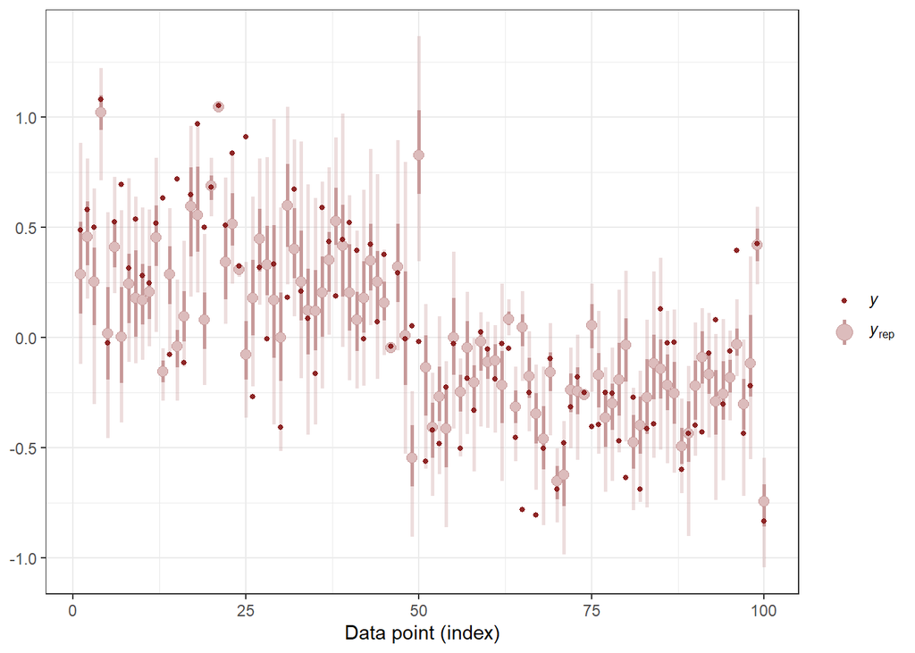

```r
ppc_intervals(y = gen_data$Phi |> list_transpose() |> list_c(),
              yrep = mssm_fit$draws(variables = "Phi", format = "draws_matrix"))
```

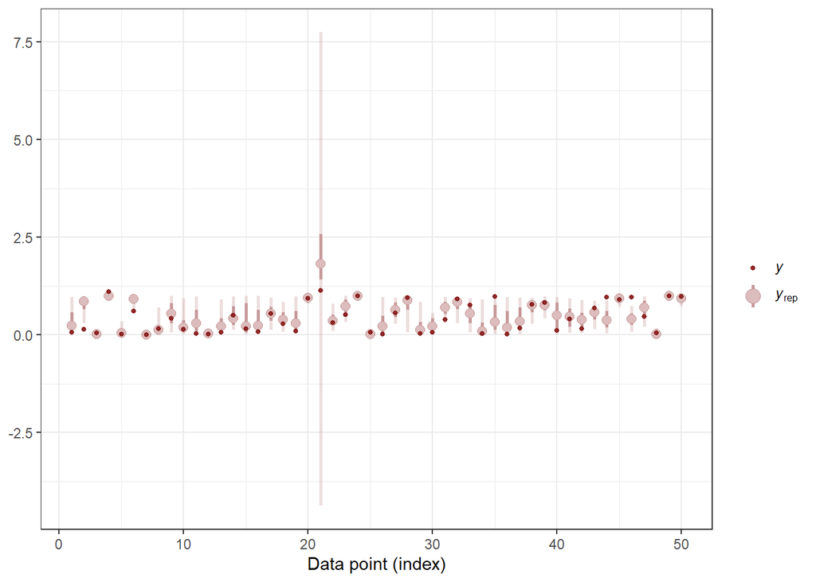

```r
ppc_intervals(y = gen_data$rel_W |> list_transpose() |> list_c(),
              yrep = mssm_fit$draws(variables = "rel_W",
                                    format = "draws_matrix"))
```

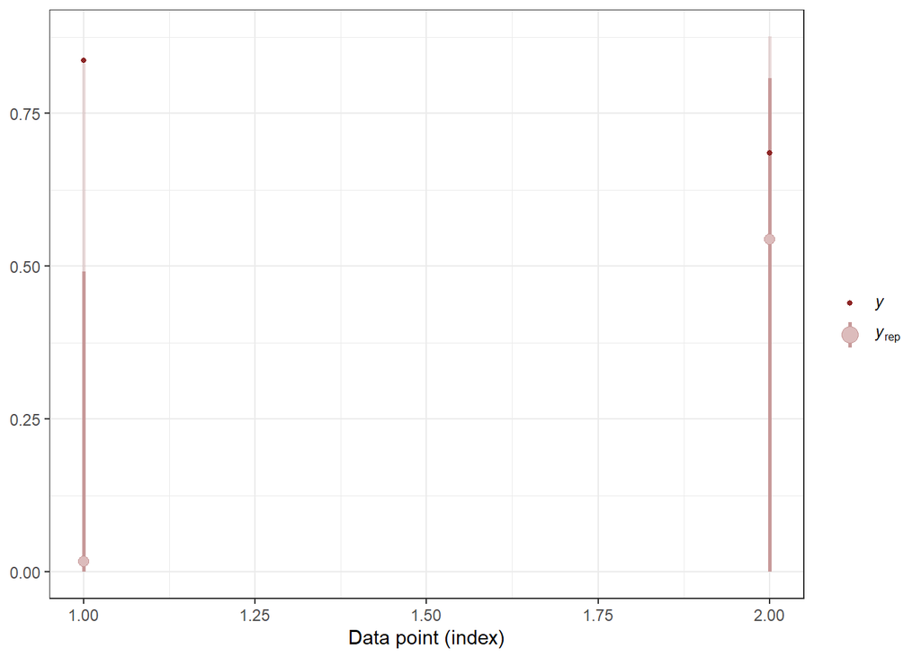

```r
ppc_intervals(y = gen_data$rel_B,
              yrep = mssm_fit$draws(variables = "rel_B",
                                    format = "draws_matrix"))
```

### 2.2.4 Evaluation … (Skip)

## 2.3 Dynamic linear model

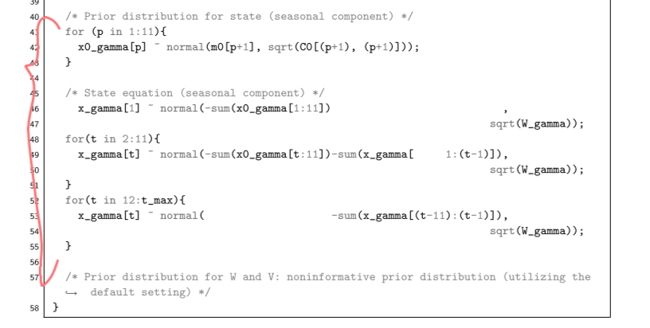

(a) Stan code

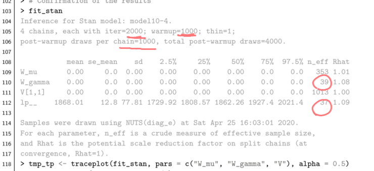

(b) MCMC summary

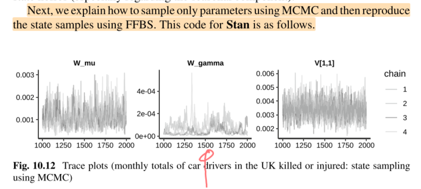

(c) Trace plots

Figure 5: Deterioration of the convergence

Hagiwara (2021) proposes that sample only parameters using MCMC and then reproduce the state samples more efficient using *forward filtering backward sampling* (FFBS). As the name suggests, this method performs Kalman filtering once in the time forward direction and then draws a sample based on Kalman smoothing in the time reverse direction. It is sometimes referred to as simulation smoothing because it corresponds to a simulation version of Kalman smoothing.

> `Stan` prepares a function `gaussian_dlm_obs()` to calculate the likelihood of the linear Gaussian state-space model. This function was implemented as Dr. Jeffrey B. Arnold’s contribution and executes Kalman filtering internally. This function in the Stan 2.19.2 does not yet support time-varying models and missing observations.

> Note that the library `dlm` provides the function `dlmBSample()` to execute FFBS. This function calculates Kalman smoothing internally.

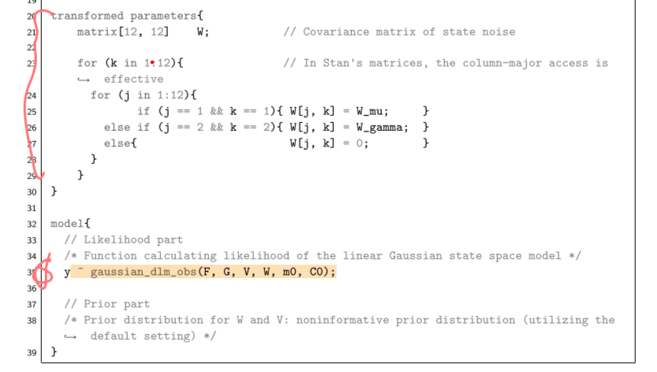

(a) Stan code

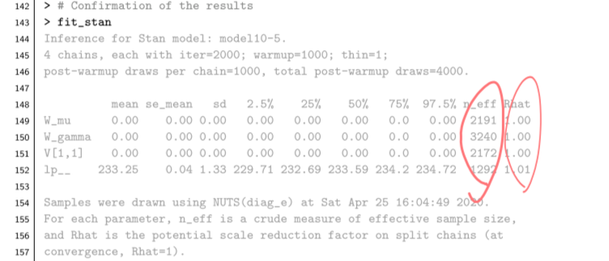

(b) MCMC summary

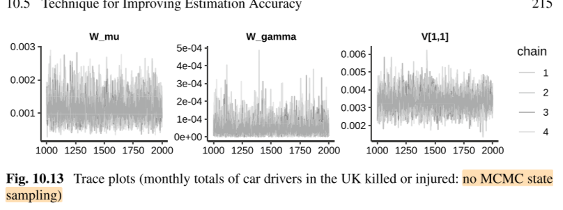

(c) Trace plots

Figure 6: No state sampling with MCMC

[output not shown]

```r
dlm_lkj <- cmdstan_model("stan/multilevel_multivariate_dlm_lkj.stan")

mssm_data <- lst(N = gen_data$N,
                 `T` = gen_data$nT,
                 y = gen_data$y)

output_dir <- "stan/results/dlm_w1s1_s1294"
dir.create(output_dir)

dlm_lkj_fit <- dlm_lkj$sample(data = mssm_data,
                        chains = 6,
                        parallel_chains = 6,
                        iter_warmup = 1000,
                        iter_sampling = 1000,
                        seed = 1294,
                        refresh = 2000,
                        show_messages = TRUE,
                        output_dir = output_dir)

saveRDS(dlm_lkj_fit$summary(), str_c(output_dir,"/summary.RDS"))
```

```r
output_dir <- "stan/results/dlm_w1s1_s1294"
dlm_lkj_fit <- as_cmdstan_fit(list.files(output_dir, "*.csv", full.names = TRUE))
dlm_lkj_sum <- readRDS(str_c(output_dir, "/summary.RDS"))
skimr::skim(dlm_lkj_sum |> select(rhat:ess_tail))
```

Data summary

| Name | select(dlm_lkj_sum, rhat:… |
| --- | --- |
| Number of rows | 3541 |
| Number of columns | 3 |
| _______________________ |  |
| Column type frequency: |  |
| numeric | 3 |
| ________________________ |  |
| Group variables | None |

**Variable type: numeric**

| skim_variable | n_missing | complete_rate | mean | sd | p0 | p25 | p50 | p75 | p100 | hist |
| --- | --- | --- | --- | --- | --- | --- | --- | --- | --- | --- |
| rhat | 2650 | 0.25 | 25.14 | 11.22 | 3.97 | 17.95 | 28.07 | 35.80 | 93.33 | ▅▇▁▁▁ |
| ess_bulk | 2650 | 0.25 | 6.11 | 0.20 | 6.05 | 6.06 | 6.06 | 6.14 | 10.89 | ▇▁▁▁▁ |
| ess_tail | 3391 | 0.04 | 6.10 | 0.48 | 6.05 | 6.05 | 6.05 | 6.05 | 11.92 | ▇▁▁▁▁ |

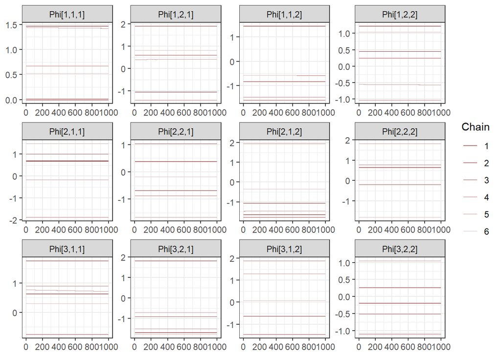

```r
dlm_lkj_fit$draws(variables = c("Phi"), format = "df") %>%
  select(kronecker(1:3, c(0, 25, 50, 75), "+"),
         .chain, .iteration, .draw) %>%
  mcmc_trace()
```

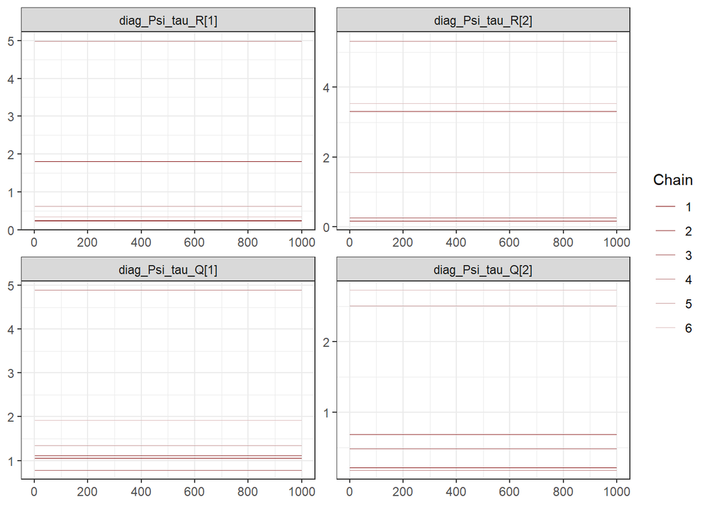

```r
dlm_lkj_fit$draws(variables = c("diag_Psi_tau_R", "diag_Psi_tau_Q"), format = "df") %>%
  mcmc_trace()
```

## References

Hagiwara, J. (2021). *Time series analysis for the state-space model with R/Stan*. Springer. https://doi.org/10.1007/978-981-16-0711-0

Schuurman, N. K., & Hamaker, E. L. (2019). Measurement error and person-specific reliability in multilevel autoregressive modeling. *Psychological Methods*, *24*(1), 70–91. https://doi.org/10.1037/met0000188